# Домашняя работа №8, Плеханов Антон 316

**Проверка наличия мультиколлинеарности признаков с помощью корреляционной матрицы и фактора инфляции дисперсии**

Загрузка данных:

```r
file <- file.choose()
data <- read.csv(file)
```

Структура данных:

```r
str(data)
```

```
## 'data.frame':    12181 obs. of  22 variables:
##  $ price                : int  8000000 7200000 10300000 8500000 9000000 8050000 10900000 8100000 10000000 9000000 ...
##  $ repair               : int  3 2 2 2 2 2 2 2 3 3 ...
##  $ year_built_empty     : int  0 0 0 0 0 0 0 0 0 0 ...
##  $ house_age            : int  42 43 43 43 43 38 35 32 45 44 ...
##  $ closest_subway       : int  59 59 59 59 59 59 59 59 59 59 ...
##  $ dist_to_subway       : int  960 802 638 929 785 962 556 859 1323 796 ...
##  $ sg                   : num  0 0 0 0 0 0 0 0 0 0 ...
##  $ lat                  : num  55.6 55.6 55.6 55.6 55.6 ...
##  $ lon                  : num  37.7 37.7 37.7 37.7 37.7 ...
##  $ subway_dist_to_center: int  17166 17166 17166 17166 17166 17166 17166 17166 17166 17166 ...
##  $ h3                   : chr  "861181b6fffffff" "861181b4fffffff" "861181b4fffffff" "861181b6fffffff" ...
##  $ agent_offers         : int  1 1 57 292 292 292 57 36 65 1 ...
##  $ subway_offers        : int  5 9 9 5 5 5 9 13 6 9 ...
##  $ address_offers       : num  1 1 2 1 1 1 1 1 1 1 ...
##  $ rooms                : int  1 1 2 2 2 1 2 1 2 2 ...
##  $ footage              : num  39.4 35.6 53 44.1 44.2 39.5 57 33.9 45.9 45.8 ...
##  $ floor                : int  11 2 5 8 6 1 19 2 10 6 ...
##  $ max_floor            : int  12 9 12 9 9 12 22 22 12 12 ...
##  $ first_floor          : int  0 0 0 0 0 1 0 0 0 0 ...
##  $ last_floor           : int  0 0 0 0 0 0 0 0 0 0 ...
##  $ AO                   : chr  "UAO" "UAO" "UAO" "UAO" ...
##  $ hm                   : chr  "panel" "panel" "panel" "panel" ...
```

Для числовых признаков построим матрицу корреляций:

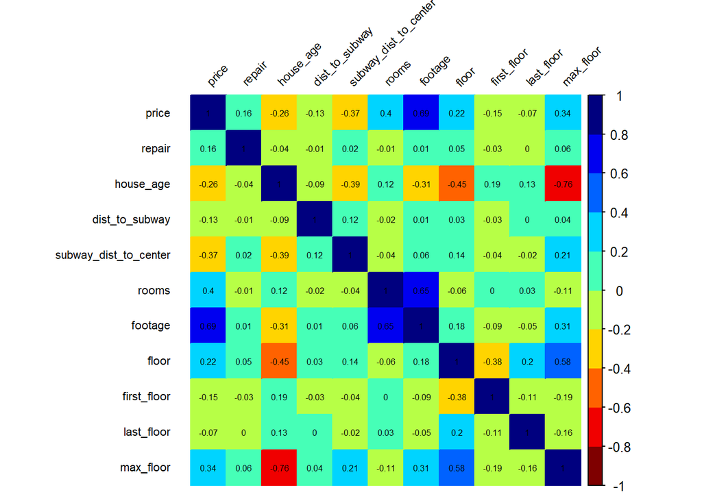

```r
library(corrplot)
numeric_features <- c("price", "repair", "house_age", "dist_to_subway",
                      "subway_dist_to_center", "rooms", "footage",
                      "floor", "first_floor", "last_floor", "max_floor")

numeric_data <- data[, numeric_features]

for (column in colnames(numeric_data)) {
  numeric_data[, column] <- as.numeric(numeric_data[, column])
}

M <- cor(numeric_data)
col4 <- colorRampPalette(c("#7F0000", "red", "#FF7F00", "yellow",
                           "#7FFF7F", "cyan", "#007FFF", "blue","#00007F"))
corrplot(M, method = "color", col = col4(10), cl.length = 11,
         order = "original",  addCoef.col = "black",
         number.font = 1, number.cex = 0.5,
         tl.cex = 0.7, tl.srt = 45, tl.col = "black", tl.offset = 1)
```

Проверка мультиколлинеарности с помощью фактора инфляции дисперсии. В качестве целевого признака выступает признак price.

```r
library(car)
vif(lm(price ~ repair + house_age + dist_to_subway +
         subway_dist_to_center + rooms + footage + floor +
         first_floor + last_floor + max_floor, data = data))
```

```
##                repair             house_age        dist_to_subway
##              1.005235              2.940965              1.017627
## subway_dist_to_center                 rooms               footage
##              1.214787              2.237808              2.483069
##                 floor           first_floor            last_floor
##              1.915133              1.176516              1.192207
##             max_floor
##              3.161492
```

Максимальные значения фактора инфляции дисперсии для признаков max_floor (3.161492) и house_age (2.940965). Из предыдущего графика мы также выяснили, что коэффициент корреляции между ними достаточно высок (по модулю): -0.76. Поэтому имеет смысл удалить признак max_floor из линейной модели:

```r
vif(lm(price ~ repair + house_age + dist_to_subway +
         subway_dist_to_center + rooms + footage + floor +
         first_floor + last_floor, data = data))
```

```
##                repair             house_age        dist_to_subway
##              1.003671              1.935576              1.017060
## subway_dist_to_center                 rooms               footage
##              1.201250              2.200227              2.424392
##                 floor           first_floor            last_floor
##              1.540887              1.171526              1.126731
```

Итого: все значения фактора инфляции дисперсии ниже 2.5.

**Взаимосвязи между признаками**

Исследуем взаимосвязи между признаками с помощью диаграмм рассеяния:

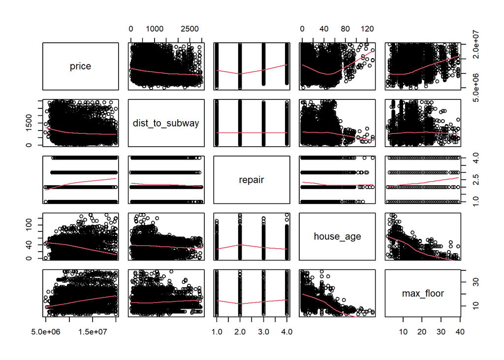

```r
pairs(data[, c("price", "dist_to_subway", "repair", "house_age", "max_floor")], panel = panel.smooth)
```

Исходя из построенных графиков, явная обратная связь прослеживается между признаками max_floor и house_age, также присутствует слабая обратная связь между признаками price и dist_to_subway и слабая прямая связь между признаками price и max_floor.

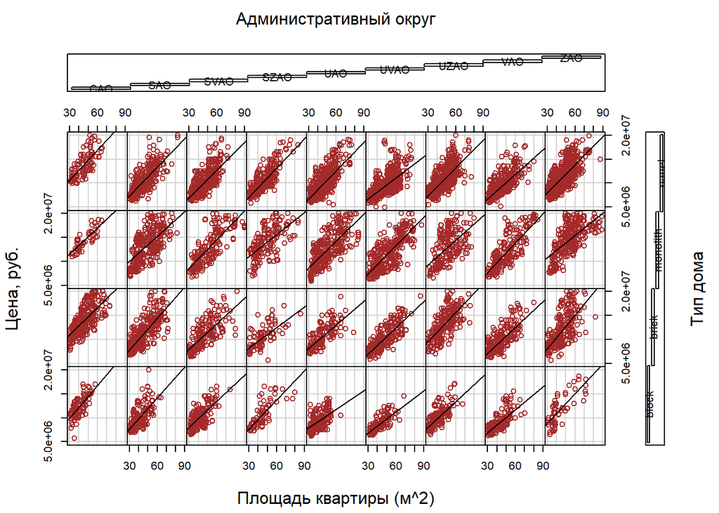

```r
coplot(data$price ~  data$footage | data$AO * as.factor(data$hm),
       ylab = c("Цена, руб.", "Тип дома"),
       xlab = c("Площадь квартиры (м^2)", "Административный округ"),
       panel = function(x, y, ...) {
         tmp <- lm(y ~ x, na.action = na.omit)
         points(x, y, col="brown")
         abline(tmp) })
```

Прямая взаимосвязь между признаками price и footage не зависит от типа дома и административного округа. В то же время из построенной диаграммы можем заключить, что квартиры с площадью выше 70 кв.м. в большинстве располагаются в домах типа monolith.

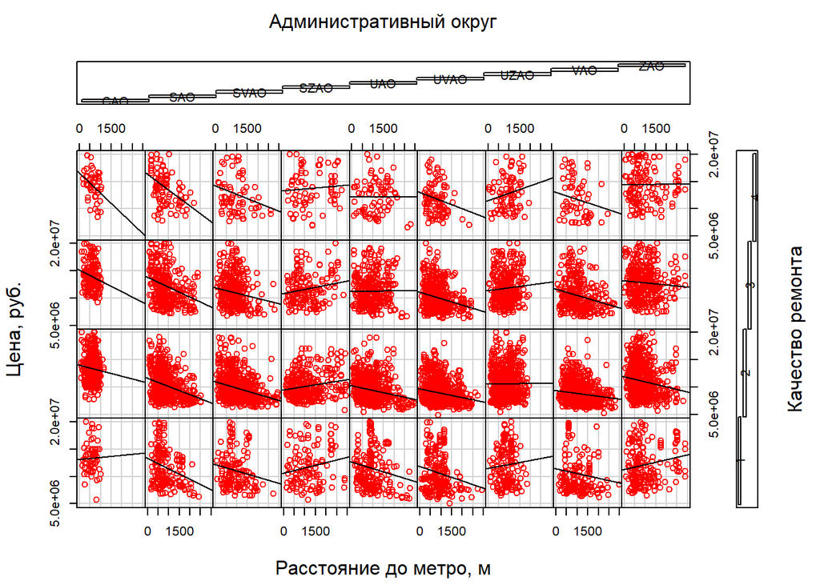

```r
data$repair <- as.factor(data$repair)
coplot(price ~ dist_to_subway | AO * repair, data = data,
       xlab = c("Расстояние до метро, м", "Административный округ"),
       ylab = c("Цена, руб.", "Качество ремонта"),
       panel = function(x, y, ...) {
         tmp <- lm(y ~ x, na.action = na.omit)
         points(x, y, col="red")
         abline(tmp) })
```

Как и ожидалось, в большинстве административных округов зависимость между ценой и расстоянием до метро обратная.

**Дисперсионный анализ**

Выясним с помощью однофакторного дисперсионного анализа, оказывает ли влияние на цену фактор hm типа дома (block, brick, monolith, panel).

Для начала построим boxplot для распределния цены в зависимсоти от типа дома:

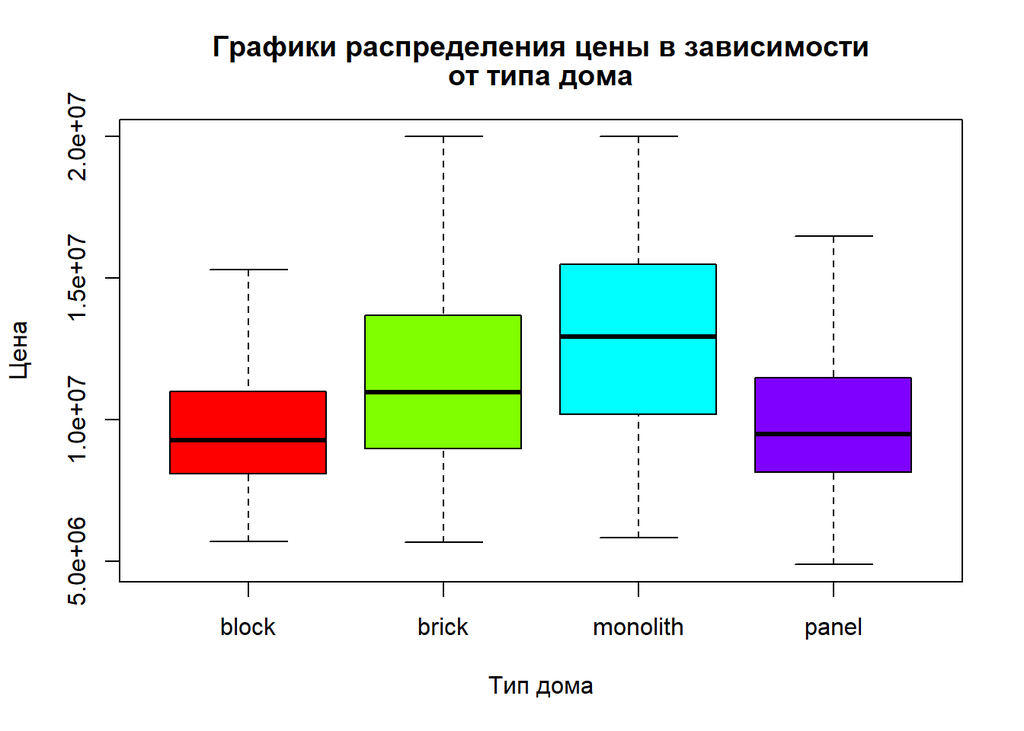

```r
data$hm <- as.factor(data$hm)
boxplot(price ~ hm, data, main = c("Графики распределения цены в зависимости", "от типа дома"), xlab = "Тип дома", ylab = "Цена", cex=0.5, col = rainbow(length(levels(data$hm))), outline = FALSE)
```

Исходя из того, насколько отличаются медианы цен, а также объема данных (всего более 12000 объектов) уже можно предположить, что различие между средними окажутся значимымми.

Проверим это с помощью соотвествующего статистического теста:

```r
M <- aov(price ~ hm, data = data)
summary(M)
```

```
##                Df    Sum Sq   Mean Sq F value Pr(>F)
## hm              3 1.716e+16 5.721e+15   731.7 <2e-16 ***
## Residuals   12177 9.520e+16 7.818e+12
## ---
## Signif. codes:  0 '***' 0.001 '**' 0.01 '*' 0.05 '.' 0.1 ' ' 1
```

p-value < 0.05, значит, фактор типа дома оказывает влияние на цену.

Проведем аналогичный анализ для фактора административного округа:

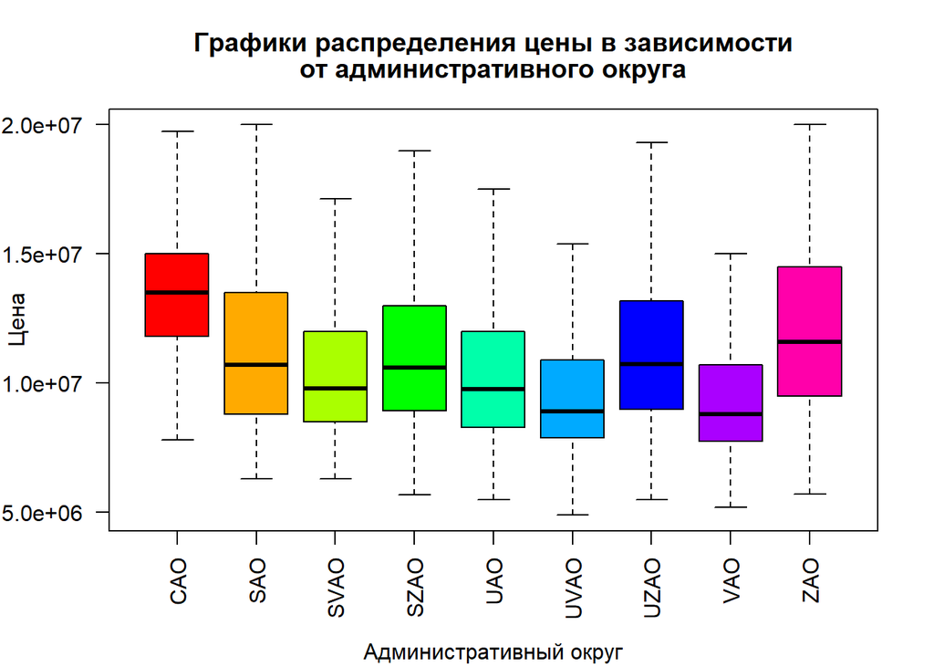

```r
data$AO <- as.factor(data$AO)
boxplot(data$price ~ data$AO, main = c("Графики распределения цены в зависимости", "от административного округа"), xlab = "", ylab = "Цена", las = 2, cex=0.5, col = rainbow(length(levels(data$AO))), outline = FALSE)
mtext("Административный округ", side = 1, line = 4)
```

```r
summary(aov(price ~ AO, data = data))
```

```
##                Df    Sum Sq   Mean Sq F value Pr(>F)
## AO              8 1.349e+16 1.687e+15   207.7 <2e-16 ***
## Residuals   12172 9.887e+16 8.123e+12
## ---
## Signif. codes:  0 '***' 0.001 '**' 0.01 '*' 0.05 '.' 0.1 ' ' 1
```

p-value < 0.05, значит, фактор административного округа оказывает влияние на цену.